# Risk Factor Analysis

## Outcome Variable

**Outcome Variable:** ever_co

## Predictor Variables

**Intervention Variable:** hhwealth_quart

**Adjustment Set:**

- arm
- sex
- W_mage
- meducyrs
- feducyrs
- W_gagebrth
- W_birthwt
- W_birthlen
- W_nchldlt5
- W_parity
- delta_W_mage
- delta_meducyrs
- delta_feducyrs
- delta_W_gagebrth
- delta_W_birthwt
- delta_W_birthlen
- delta_W_nchldlt5
- delta_W_parity

## Stratifying Variables

The analysis was stratified on these variable(s):

- agecat
- studyid
- country

## Data Summary

| agecat | studyid | country | hhwealth_quart | ever_co | n_cell | n |
| --- | --- | --- | --- | --- | --- | --- |
| 0-24 months | ki0047075b-MAL-ED | BANGLADESH | Wealth Q4 | 0 | 55 | 242 |
| 0-24 months | ki0047075b-MAL-ED | BANGLADESH | Wealth Q4 | 1 | 6 | 242 |
| 0-24 months | ki0047075b-MAL-ED | BANGLADESH | Wealth Q1 | 0 | 51 | 242 |
| 0-24 months | ki0047075b-MAL-ED | BANGLADESH | Wealth Q1 | 1 | 9 | 242 |
| 0-24 months | ki0047075b-MAL-ED | BANGLADESH | Wealth Q2 | 0 | 46 | 242 |
| 0-24 months | ki0047075b-MAL-ED | BANGLADESH | Wealth Q2 | 1 | 15 | 242 |
| 0-24 months | ki0047075b-MAL-ED | BANGLADESH | Wealth Q3 | 0 | 51 | 242 |
| 0-24 months | ki0047075b-MAL-ED | BANGLADESH | Wealth Q3 | 1 | 9 | 242 |
| 0-24 months | ki0047075b-MAL-ED | BRAZIL | Wealth Q4 | 0 | 52 | 210 |
| 0-24 months | ki0047075b-MAL-ED | BRAZIL | Wealth Q4 | 1 | 1 | 210 |
| 0-24 months | ki0047075b-MAL-ED | BRAZIL | Wealth Q1 | 0 | 53 | 210 |
| 0-24 months | ki0047075b-MAL-ED | BRAZIL | Wealth Q1 | 1 | 0 | 210 |
| 0-24 months | ki0047075b-MAL-ED | BRAZIL | Wealth Q2 | 0 | 52 | 210 |
| 0-24 months | ki0047075b-MAL-ED | BRAZIL | Wealth Q2 | 1 | 1 | 210 |
| 0-24 months | ki0047075b-MAL-ED | BRAZIL | Wealth Q3 | 0 | 50 | 210 |
| 0-24 months | ki0047075b-MAL-ED | BRAZIL | Wealth Q3 | 1 | 1 | 210 |
| 0-24 months | ki0047075b-MAL-ED | INDIA | Wealth Q4 | 0 | 49 | 235 |
| 0-24 months | ki0047075b-MAL-ED | INDIA | Wealth Q4 | 1 | 10 | 235 |
| 0-24 months | ki0047075b-MAL-ED | INDIA | Wealth Q1 | 0 | 45 | 235 |
| 0-24 months | ki0047075b-MAL-ED | INDIA | Wealth Q1 | 1 | 15 | 235 |
| 0-24 months | ki0047075b-MAL-ED | INDIA | Wealth Q2 | 0 | 43 | 235 |
| 0-24 months | ki0047075b-MAL-ED | INDIA | Wealth Q2 | 1 | 15 | 235 |
| 0-24 months | ki0047075b-MAL-ED | INDIA | Wealth Q3 | 0 | 45 | 235 |
| 0-24 months | ki0047075b-MAL-ED | INDIA | Wealth Q3 | 1 | 13 | 235 |
| 0-24 months | ki0047075b-MAL-ED | NEPAL | Wealth Q4 | 0 | 55 | 236 |
| 0-24 months | ki0047075b-MAL-ED | NEPAL | Wealth Q4 | 1 | 4 | 236 |
| 0-24 months | ki0047075b-MAL-ED | NEPAL | Wealth Q1 | 0 | 55 | 236 |
| 0-24 months | ki0047075b-MAL-ED | NEPAL | Wealth Q1 | 1 | 4 | 236 |
| 0-24 months | ki0047075b-MAL-ED | NEPAL | Wealth Q2 | 0 | 56 | 236 |
| 0-24 months | ki0047075b-MAL-ED | NEPAL | Wealth Q2 | 1 | 3 | 236 |

[output cut: 402 more lines]

The following strata were considered:

- agecat: 0-24 months, studyid: ki0047075b-MAL-ED, country: BANGLADESH
- agecat: 0-24 months, studyid: ki0047075b-MAL-ED, country: BRAZIL
- agecat: 0-24 months, studyid: ki0047075b-MAL-ED, country: INDIA
- agecat: 0-24 months, studyid: ki0047075b-MAL-ED, country: NEPAL
- agecat: 0-24 months, studyid: ki0047075b-MAL-ED, country: PERU
- agecat: 0-24 months, studyid: ki0047075b-MAL-ED, country: SOUTH AFRICA
- agecat: 0-24 months, studyid: ki0047075b-MAL-ED, country: TANZANIA, UNITED REPUBLIC OF
- agecat: 0-24 months, studyid: ki1000108-CMC-V-BCS-2002, country: INDIA
- agecat: 0-24 months, studyid: ki1000108-IRC, country: INDIA
- agecat: 0-24 months, studyid: ki1017093b-PROVIDE, country: BANGLADESH
- agecat: 0-24 months, studyid: ki1066203-TanzaniaChild2, country: TANZANIA, UNITED REPUBLIC OF
- agecat: 0-24 months, studyid: ki1113344-GMS-Nepal, country: NEPAL
- agecat: 0-24 months, studyid: ki1114097-CONTENT, country: PERU
- agecat: 0-24 months, studyid: ki1135781-COHORTS, country: GUATEMALA
- agecat: 0-24 months, studyid: ki1135781-COHORTS, country: PHILIPPINES
- agecat: 0-24 months, studyid: ki1148112-LCNI-5, country: MALAWI
- agecat: 0-24 months, studyid: kiGH5241-JiVitA-3, country: BANGLADESH
- agecat: 0-24 months, studyid: kiGH5241-JiVitA-4, country: BANGLADESH
- agecat: 0-6 months, studyid: ki0047075b-MAL-ED, country: BANGLADESH
- agecat: 0-6 months, studyid: ki0047075b-MAL-ED, country: BRAZIL
- agecat: 0-6 months, studyid: ki0047075b-MAL-ED, country: INDIA
- agecat: 0-6 months, studyid: ki0047075b-MAL-ED, country: NEPAL
- agecat: 0-6 months, studyid: ki0047075b-MAL-ED, country: PERU
- agecat: 0-6 months, studyid: ki0047075b-MAL-ED, country: SOUTH AFRICA
- agecat: 0-6 months, studyid: ki0047075b-MAL-ED, country: TANZANIA, UNITED REPUBLIC OF
- agecat: 0-6 months, studyid: ki1000108-CMC-V-BCS-2002, country: INDIA
- agecat: 0-6 months, studyid: ki1000108-IRC, country: INDIA
- agecat: 0-6 months, studyid: ki1017093b-PROVIDE, country: BANGLADESH
- agecat: 0-6 months, studyid: ki1066203-TanzaniaChild2, country: TANZANIA, UNITED REPUBLIC OF
- agecat: 0-6 months, studyid: ki1113344-GMS-Nepal, country: NEPAL
- agecat: 0-6 months, studyid: ki1114097-CONTENT, country: PERU
- agecat: 0-6 months, studyid: ki1135781-COHORTS, country: GUATEMALA
- agecat: 0-6 months, studyid: ki1135781-COHORTS, country: PHILIPPINES
- agecat: 0-6 months, studyid: ki1148112-LCNI-5, country: MALAWI
- agecat: 0-6 months, studyid: kiGH5241-JiVitA-3, country: BANGLADESH
- agecat: 0-6 months, studyid: kiGH5241-JiVitA-4, country: BANGLADESH
- agecat: 6-24 months, studyid: ki0047075b-MAL-ED, country: BANGLADESH
- agecat: 6-24 months, studyid: ki0047075b-MAL-ED, country: BRAZIL
- agecat: 6-24 months, studyid: ki0047075b-MAL-ED, country: INDIA
- agecat: 6-24 months, studyid: ki0047075b-MAL-ED, country: NEPAL
- agecat: 6-24 months, studyid: ki0047075b-MAL-ED, country: PERU
- agecat: 6-24 months, studyid: ki0047075b-MAL-ED, country: SOUTH AFRICA
- agecat: 6-24 months, studyid: ki0047075b-MAL-ED, country: TANZANIA, UNITED REPUBLIC OF
- agecat: 6-24 months, studyid: ki1000108-CMC-V-BCS-2002, country: INDIA
- agecat: 6-24 months, studyid: ki1000108-IRC, country: INDIA
- agecat: 6-24 months, studyid: ki1017093b-PROVIDE, country: BANGLADESH
- agecat: 6-24 months, studyid: ki1066203-TanzaniaChild2, country: TANZANIA, UNITED REPUBLIC OF
- agecat: 6-24 months, studyid: ki1113344-GMS-Nepal, country: NEPAL
- agecat: 6-24 months, studyid: ki1114097-CONTENT, country: PERU
- agecat: 6-24 months, studyid: ki1135781-COHORTS, country: GUATEMALA
- agecat: 6-24 months, studyid: ki1135781-COHORTS, country: PHILIPPINES
- agecat: 6-24 months, studyid: ki1148112-LCNI-5, country: MALAWI
- agecat: 6-24 months, studyid: kiGH5241-JiVitA-3, country: BANGLADESH
- agecat: 6-24 months, studyid: kiGH5241-JiVitA-4, country: BANGLADESH

### Dropped Strata

Some strata were dropped due to rare outcomes:

- agecat: 0-24 months, studyid: ki0047075b-MAL-ED, country: BRAZIL
- agecat: 0-24 months, studyid: ki0047075b-MAL-ED, country: NEPAL
- agecat: 0-24 months, studyid: ki0047075b-MAL-ED, country: PERU
- agecat: 0-24 months, studyid: ki0047075b-MAL-ED, country: SOUTH AFRICA
- agecat: 0-24 months, studyid: ki0047075b-MAL-ED, country: TANZANIA, UNITED REPUBLIC OF
- agecat: 0-24 months, studyid: ki1114097-CONTENT, country: PERU
- agecat: 0-6 months, studyid: ki0047075b-MAL-ED, country: BANGLADESH
- agecat: 0-6 months, studyid: ki0047075b-MAL-ED, country: BRAZIL
- agecat: 0-6 months, studyid: ki0047075b-MAL-ED, country: INDIA
- agecat: 0-6 months, studyid: ki0047075b-MAL-ED, country: NEPAL
- agecat: 0-6 months, studyid: ki0047075b-MAL-ED, country: PERU
- agecat: 0-6 months, studyid: ki0047075b-MAL-ED, country: SOUTH AFRICA
- agecat: 0-6 months, studyid: ki0047075b-MAL-ED, country: TANZANIA, UNITED REPUBLIC OF
- agecat: 0-6 months, studyid: ki1000108-CMC-V-BCS-2002, country: INDIA
- agecat: 0-6 months, studyid: ki1017093b-PROVIDE, country: BANGLADESH
- agecat: 0-6 months, studyid: ki1066203-TanzaniaChild2, country: TANZANIA, UNITED REPUBLIC OF
- agecat: 0-6 months, studyid: ki1114097-CONTENT, country: PERU
- agecat: 0-6 months, studyid: ki1135781-COHORTS, country: GUATEMALA
- agecat: 0-6 months, studyid: ki1148112-LCNI-5, country: MALAWI
- agecat: 6-24 months, studyid: ki0047075b-MAL-ED, country: BRAZIL
- agecat: 6-24 months, studyid: ki0047075b-MAL-ED, country: NEPAL
- agecat: 6-24 months, studyid: ki0047075b-MAL-ED, country: PERU
- agecat: 6-24 months, studyid: ki0047075b-MAL-ED, country: SOUTH AFRICA
- agecat: 6-24 months, studyid: ki0047075b-MAL-ED, country: TANZANIA, UNITED REPUBLIC OF
- agecat: 6-24 months, studyid: ki1114097-CONTENT, country: PERU

## Methods Detail

We’re interested in the causal parameters $E[Y_a]$ for all values of $a \in \mathcal{A}$. These parameters represent the mean outcome if, possibly contrary to fact, we intervened to set all units to have $A=a$. Under the randomization and positivity assumptions, these are identified by the statistical parameters $\psi_a=E_W[E_{Y|A,W}(Y|A=a,W)]$. In addition, we’re interested in the mean of $Y$, $E[Y]$ under no intervention (the observed mean). We will estimate these parameters by using SuperLearner to fit the relevant likelihood factors – $E_{Y|A,W}(Y|A=a,W)$ and $p(A=a|W)$, and then updating our likelihood fit using a joint TMLE.

For unadjusted analyses ($W=\{\}$), initial likelihoods were estimated using Lrnr_glm to estimate the simple $E(Y|A)$ and Lrnr_mean to estimate $p(A)$. For adjusted analyses, a small library containing Lrnr_glmnet, Lrnr_xgboost, and Lrnr_mean was used.

Having estimated these parameters, we will then use the delta method to estimate relative risks and attributable risks relative to a prespecified baseline level of $A$.

# Results Detail

## Results Plots

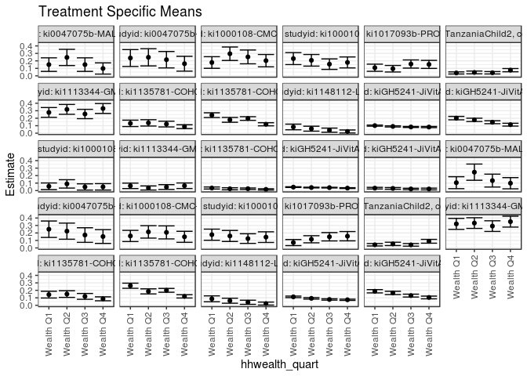

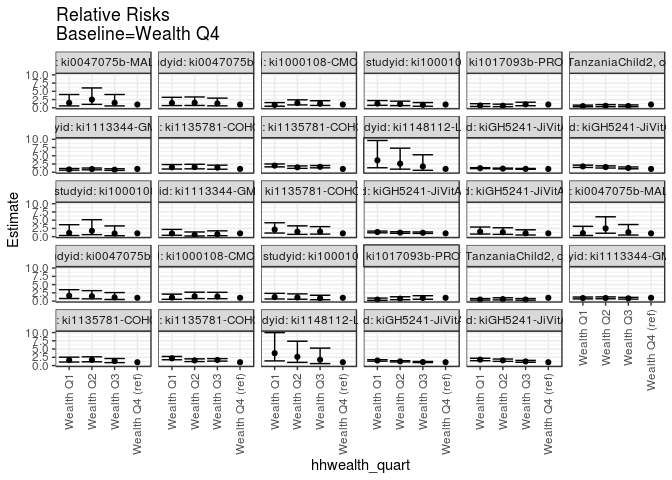

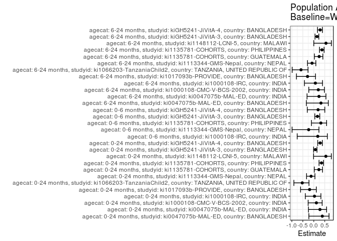

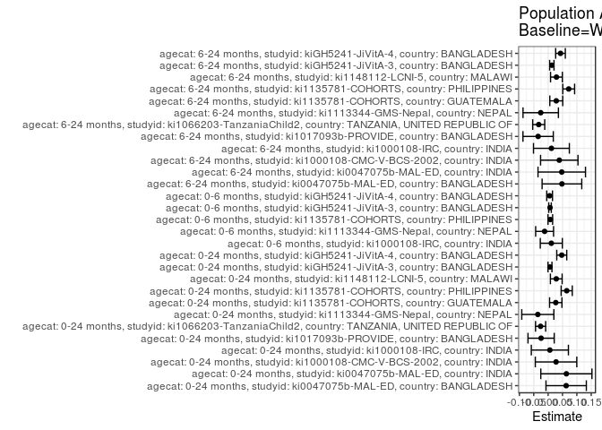

## Results Table

### Parameter: TSM

| agecat | studyid | country | intervention_level | baseline_level | estimate | ci_lower | ci_upper |
| --- | --- | --- | --- | --- | --- | --- | --- |
| 0-24 months | ki0047075b-MAL-ED | BANGLADESH | Wealth Q4 | NA | 0.0983607 | 0.0234731 | 0.1732482 |
| 0-24 months | ki0047075b-MAL-ED | BANGLADESH | Wealth Q1 | NA | 0.1500000 | 0.0594629 | 0.2405371 |
| 0-24 months | ki0047075b-MAL-ED | BANGLADESH | Wealth Q2 | NA | 0.2459016 | 0.1376145 | 0.3541888 |
| 0-24 months | ki0047075b-MAL-ED | BANGLADESH | Wealth Q3 | NA | 0.1500000 | 0.0594629 | 0.2405371 |
| 0-24 months | ki0047075b-MAL-ED | INDIA | Wealth Q4 | NA | 0.1619989 | 0.0628454 | 0.2611524 |
| 0-24 months | ki0047075b-MAL-ED | INDIA | Wealth Q1 | NA | 0.2382302 | 0.1255910 | 0.3508694 |
| 0-24 months | ki0047075b-MAL-ED | INDIA | Wealth Q2 | NA | 0.2476152 | 0.1327130 | 0.3625174 |
| 0-24 months | ki0047075b-MAL-ED | INDIA | Wealth Q3 | NA | 0.2156902 | 0.1060182 | 0.3253623 |
| 0-24 months | ki1000108-CMC-V-BCS-2002 | INDIA | Wealth Q4 | NA | 0.2029490 | 0.1206254 | 0.2852725 |
| 0-24 months | ki1000108-CMC-V-BCS-2002 | INDIA | Wealth Q1 | NA | 0.1783399 | 0.1007084 | 0.2559714 |
| 0-24 months | ki1000108-CMC-V-BCS-2002 | INDIA | Wealth Q2 | NA | 0.2952515 | 0.2052495 | 0.3852535 |
| 0-24 months | ki1000108-CMC-V-BCS-2002 | INDIA | Wealth Q3 | NA | 0.2530866 | 0.1609599 | 0.3452134 |
| 0-24 months | ki1000108-IRC | INDIA | Wealth Q4 | NA | 0.1792946 | 0.1059807 | 0.2526085 |
| 0-24 months | ki1000108-IRC | INDIA | Wealth Q1 | NA | 0.2304002 | 0.1505389 | 0.3102615 |
| 0-24 months | ki1000108-IRC | INDIA | Wealth Q2 | NA | 0.2075243 | 0.1300192 | 0.2850293 |
| 0-24 months | ki1000108-IRC | INDIA | Wealth Q3 | NA | 0.1560625 | 0.0859572 | 0.2261679 |
| 0-24 months | ki1017093b-PROVIDE | BANGLADESH | Wealth Q4 | NA | 0.1529842 | 0.0992025 | 0.2067659 |
| 0-24 months | ki1017093b-PROVIDE | BANGLADESH | Wealth Q1 | NA | 0.1084650 | 0.0605895 | 0.1563405 |
| 0-24 months | ki1017093b-PROVIDE | BANGLADESH | Wealth Q2 | NA | 0.0952379 | 0.0516140 | 0.1388618 |
| 0-24 months | ki1017093b-PROVIDE | BANGLADESH | Wealth Q3 | NA | 0.1579118 | 0.1033838 | 0.2124398 |
| 0-24 months | ki1066203-TanzaniaChild2 | TANZANIA, UNITED REPUBLIC OF | Wealth Q4 | NA | 0.0760928 | 0.0546254 | 0.0975601 |
| 0-24 months | ki1066203-TanzaniaChild2 | TANZANIA, UNITED REPUBLIC OF | Wealth Q1 | NA | 0.0388639 | 0.0247301 | 0.0529977 |
| 0-24 months | ki1066203-TanzaniaChild2 | TANZANIA, UNITED REPUBLIC OF | Wealth Q2 | NA | 0.0454083 | 0.0268947 | 0.0639219 |
| 0-24 months | ki1066203-TanzaniaChild2 | TANZANIA, UNITED REPUBLIC OF | Wealth Q3 | NA | 0.0410745 | 0.0251503 | 0.0569987 |
| 0-24 months | ki1113344-GMS-Nepal | NEPAL | Wealth Q4 | NA | 0.3302987 | 0.2641710 | 0.3964264 |
| 0-24 months | ki1113344-GMS-Nepal | NEPAL | Wealth Q1 | NA | 0.2775050 | 0.2121298 | 0.3428802 |
| 0-24 months | ki1113344-GMS-Nepal | NEPAL | Wealth Q2 | NA | 0.3181589 | 0.2526280 | 0.3836899 |
| 0-24 months | ki1113344-GMS-Nepal | NEPAL | Wealth Q3 | NA | 0.2566107 | 0.1943217 | 0.3188996 |
| 0-24 months | ki1135781-COHORTS | GUATEMALA | Wealth Q4 | NA | 0.0874122 | 0.0620351 | 0.1127893 |
| 0-24 months | ki1135781-COHORTS | GUATEMALA | Wealth Q1 | NA | 0.1315256 | 0.0887436 | 0.1743075 |

[output cut: 86 more lines]

### Parameter: E(Y)

| agecat | studyid | country | intervention_level | baseline_level | estimate | ci_lower | ci_upper |
| --- | --- | --- | --- | --- | --- | --- | --- |
| 0-24 months | ki0047075b-MAL-ED | BANGLADESH | NA | NA | 0.1611570 | 0.1147371 | 0.2075770 |
| 0-24 months | ki0047075b-MAL-ED | INDIA | NA | NA | 0.2255319 | 0.1719836 | 0.2790802 |
| 0-24 months | ki1000108-CMC-V-BCS-2002 | INDIA | NA | NA | 0.2305630 | 0.1877616 | 0.2733644 |
| 0-24 months | ki1000108-IRC | INDIA | NA | NA | 0.1853659 | 0.1477057 | 0.2230261 |
| 0-24 months | ki1017093b-PROVIDE | BANGLADESH | NA | NA | 0.1285714 | 0.1037574 | 0.1533855 |
| 0-24 months | ki1066203-TanzaniaChild2 | TANZANIA, UNITED REPUBLIC OF | NA | NA | 0.0499161 | 0.0411726 | 0.0586596 |
| 0-24 months | ki1113344-GMS-Nepal | NEPAL | NA | NA | 0.2944606 | 0.2603274 | 0.3285938 |
| 0-24 months | ki1135781-COHORTS | GUATEMALA | NA | NA | 0.1140143 | 0.0964790 | 0.1315495 |
| 0-24 months | ki1135781-COHORTS | PHILIPPINES | NA | NA | 0.1839685 | 0.1702020 | 0.1977349 |
| 0-24 months | ki1148112-LCNI-5 | MALAWI | NA | NA | 0.0514076 | 0.0362561 | 0.0665591 |
| 0-24 months | kiGH5241-JiVitA-3 | BANGLADESH | NA | NA | 0.0888137 | 0.0849063 | 0.0927211 |
| 0-24 months | kiGH5241-JiVitA-4 | BANGLADESH | NA | NA | 0.1614449 | 0.1501252 | 0.1727646 |
| 0-6 months | ki1000108-IRC | INDIA | NA | NA | 0.0611247 | 0.0378797 | 0.0843697 |
| 0-6 months | ki1113344-GMS-Nepal | NEPAL | NA | NA | 0.0524781 | 0.0357793 | 0.0691770 |
| 0-6 months | ki1135781-COHORTS | PHILIPPINES | NA | NA | 0.0236609 | 0.0182597 | 0.0290620 |
| 0-6 months | kiGH5241-JiVitA-3 | BANGLADESH | NA | NA | 0.0396387 | 0.0371359 | 0.0421415 |
| 0-6 months | kiGH5241-JiVitA-4 | BANGLADESH | NA | NA | 0.0263831 | 0.0210411 | 0.0317252 |
| 6-24 months | ki0047075b-MAL-ED | BANGLADESH | NA | NA | 0.1464435 | 0.1015265 | 0.1913605 |
| 6-24 months | ki0047075b-MAL-ED | INDIA | NA | NA | 0.2000000 | 0.1487493 | 0.2512507 |
| 6-24 months | ki1000108-CMC-V-BCS-2002 | INDIA | NA | NA | 0.1876676 | 0.1479906 | 0.2273445 |
| 6-24 months | ki1000108-IRC | INDIA | NA | NA | 0.1560976 | 0.1209228 | 0.1912723 |
| 6-24 months | ki1017093b-PROVIDE | BANGLADESH | NA | NA | 0.1221498 | 0.0962275 | 0.1480722 |
| 6-24 months | ki1066203-TanzaniaChild2 | TANZANIA, UNITED REPUBLIC OF | NA | NA | 0.0562469 | 0.0461696 | 0.0663242 |
| 6-24 months | ki1113344-GMS-Nepal | NEPAL | NA | NA | 0.3254237 | 0.2875855 | 0.3632619 |
| 6-24 months | ki1135781-COHORTS | GUATEMALA | NA | NA | 0.1153513 | 0.0969046 | 0.1337979 |
| 6-24 months | ki1135781-COHORTS | PHILIPPINES | NA | NA | 0.1908832 | 0.1763448 | 0.2054216 |
| 6-24 months | ki1148112-LCNI-5 | MALAWI | NA | NA | 0.0521739 | 0.0368026 | 0.0675452 |
| 6-24 months | kiGH5241-JiVitA-3 | BANGLADESH | NA | NA | 0.0867929 | 0.0821342 | 0.0914516 |
| 6-24 months | kiGH5241-JiVitA-4 | BANGLADESH | NA | NA | 0.1477315 | 0.1371478 | 0.1583151 |

### Parameter: RR

| agecat | studyid | country | intervention_level | baseline_level | estimate | ci_lower | ci_upper |
| --- | --- | --- | --- | --- | --- | --- | --- |
| 0-24 months | ki0047075b-MAL-ED | BANGLADESH | Wealth Q4 | Wealth Q4 | 1.0000000 | 1.0000000 | 1.0000000 |
| 0-24 months | ki0047075b-MAL-ED | BANGLADESH | Wealth Q1 | Wealth Q4 | 1.5250000 | 0.5771872 | 4.0292385 |
| 0-24 months | ki0047075b-MAL-ED | BANGLADESH | Wealth Q2 | Wealth Q4 | 2.4999999 | 1.0374362 | 6.0244667 |
| 0-24 months | ki0047075b-MAL-ED | BANGLADESH | Wealth Q3 | Wealth Q4 | 1.5250000 | 0.5771872 | 4.0292385 |
| 0-24 months | ki0047075b-MAL-ED | INDIA | Wealth Q4 | Wealth Q4 | 1.0000000 | 1.0000000 | 1.0000000 |
| 0-24 months | ki0047075b-MAL-ED | INDIA | Wealth Q1 | Wealth Q4 | 1.4705667 | 0.6775371 | 3.1918052 |
| 0-24 months | ki0047075b-MAL-ED | INDIA | Wealth Q2 | Wealth Q4 | 1.5284992 | 0.7094338 | 3.2932033 |
| 0-24 months | ki0047075b-MAL-ED | INDIA | Wealth Q3 | Wealth Q4 | 1.3314302 | 0.6018227 | 2.9455627 |
| 0-24 months | ki1000108-CMC-V-BCS-2002 | INDIA | Wealth Q4 | Wealth Q4 | 1.0000000 | 1.0000000 | 1.0000000 |
| 0-24 months | ki1000108-CMC-V-BCS-2002 | INDIA | Wealth Q1 | Wealth Q4 | 0.8787428 | 0.4855107 | 1.5904672 |
| 0-24 months | ki1000108-CMC-V-BCS-2002 | INDIA | Wealth Q2 | Wealth Q4 | 1.4548065 | 0.8740192 | 2.4215282 |
| 0-24 months | ki1000108-CMC-V-BCS-2002 | INDIA | Wealth Q3 | Wealth Q4 | 1.2470456 | 0.7247330 | 2.1457870 |
| 0-24 months | ki1000108-IRC | INDIA | Wealth Q4 | Wealth Q4 | 1.0000000 | 1.0000000 | 1.0000000 |
| 0-24 months | ki1000108-IRC | INDIA | Wealth Q1 | Wealth Q4 | 1.2850368 | 0.7524982 | 2.1944500 |
| 0-24 months | ki1000108-IRC | INDIA | Wealth Q2 | Wealth Q4 | 1.1574482 | 0.6655557 | 2.0128841 |
| 0-24 months | ki1000108-IRC | INDIA | Wealth Q3 | Wealth Q4 | 0.8704249 | 0.4735252 | 1.5999984 |
| 0-24 months | ki1017093b-PROVIDE | BANGLADESH | Wealth Q4 | Wealth Q4 | 1.0000000 | 1.0000000 | 1.0000000 |
| 0-24 months | ki1017093b-PROVIDE | BANGLADESH | Wealth Q1 | Wealth Q4 | 0.7089950 | 0.4031352 | 1.2469115 |
| 0-24 months | ki1017093b-PROVIDE | BANGLADESH | Wealth Q2 | Wealth Q4 | 0.6225344 | 0.3493274 | 1.1094150 |
| 0-24 months | ki1017093b-PROVIDE | BANGLADESH | Wealth Q3 | Wealth Q4 | 1.0322098 | 0.6304558 | 1.6899788 |
| 0-24 months | ki1066203-TanzaniaChild2 | TANZANIA, UNITED REPUBLIC OF | Wealth Q4 | Wealth Q4 | 1.0000000 | 1.0000000 | 1.0000000 |
| 0-24 months | ki1066203-TanzaniaChild2 | TANZANIA, UNITED REPUBLIC OF | Wealth Q1 | Wealth Q4 | 0.5107442 | 0.3225103 | 0.8088412 |
| 0-24 months | ki1066203-TanzaniaChild2 | TANZANIA, UNITED REPUBLIC OF | Wealth Q2 | Wealth Q4 | 0.5967492 | 0.3634803 | 0.9797217 |
| 0-24 months | ki1066203-TanzaniaChild2 | TANZANIA, UNITED REPUBLIC OF | Wealth Q3 | Wealth Q4 | 0.5397950 | 0.3342640 | 0.8717020 |
| 0-24 months | ki1113344-GMS-Nepal | NEPAL | Wealth Q4 | Wealth Q4 | 1.0000000 | 1.0000000 | 1.0000000 |
| 0-24 months | ki1113344-GMS-Nepal | NEPAL | Wealth Q1 | Wealth Q4 | 0.8401638 | 0.6207268 | 1.1371754 |
| 0-24 months | ki1113344-GMS-Nepal | NEPAL | Wealth Q2 | Wealth Q4 | 0.9632461 | 0.7274453 | 1.2754817 |
| 0-24 months | ki1113344-GMS-Nepal | NEPAL | Wealth Q3 | Wealth Q4 | 0.7769049 | 0.5712450 | 1.0566065 |
| 0-24 months | ki1135781-COHORTS | GUATEMALA | Wealth Q4 | Wealth Q4 | 1.0000000 | 1.0000000 | 1.0000000 |
| 0-24 months | ki1135781-COHORTS | GUATEMALA | Wealth Q1 | Wealth Q4 | 1.5046594 | 0.9733602 | 2.3259630 |

[output cut: 86 more lines]

### Parameter: PAR

| agecat | studyid | country | intervention_level | baseline_level | estimate | ci_lower | ci_upper |
| --- | --- | --- | --- | --- | --- | --- | --- |
| 0-24 months | ki0047075b-MAL-ED | BANGLADESH | Wealth Q4 | NA | 0.0627964 | -0.0074582 | 0.1330510 |
| 0-24 months | ki0047075b-MAL-ED | INDIA | Wealth Q4 | NA | 0.0635330 | -0.0254887 | 0.1525547 |
| 0-24 months | ki1000108-CMC-V-BCS-2002 | INDIA | Wealth Q4 | NA | 0.0276140 | -0.0445894 | 0.0998175 |
| 0-24 months | ki1000108-IRC | INDIA | Wealth Q4 | NA | 0.0060712 | -0.0584791 | 0.0706215 |
| 0-24 months | ki1017093b-PROVIDE | BANGLADESH | Wealth Q4 | NA | -0.0244128 | -0.0700384 | 0.0212129 |
| 0-24 months | ki1066203-TanzaniaChild2 | TANZANIA, UNITED REPUBLIC OF | Wealth Q4 | NA | -0.0261767 | -0.0437705 | -0.0085828 |
| 0-24 months | ki1113344-GMS-Nepal | NEPAL | Wealth Q4 | NA | -0.0358381 | -0.0916915 | 0.0200153 |
| 0-24 months | ki1135781-COHORTS | GUATEMALA | Wealth Q4 | NA | 0.0266021 | 0.0050960 | 0.0481081 |
| 0-24 months | ki1135781-COHORTS | PHILIPPINES | Wealth Q4 | NA | 0.0647209 | 0.0453432 | 0.0840987 |
| 0-24 months | ki1148112-LCNI-5 | MALAWI | Wealth Q4 | NA | 0.0283661 | 0.0079551 | 0.0487771 |
| 0-24 months | kiGH5241-JiVitA-3 | BANGLADESH | Wealth Q4 | NA | 0.0064560 | -0.0004082 | 0.0133203 |
| 0-24 months | kiGH5241-JiVitA-4 | BANGLADESH | Wealth Q4 | NA | 0.0474441 | 0.0300858 | 0.0648024 |
| 0-6 months | ki1000108-IRC | INDIA | Wealth Q4 | NA | 0.0111247 | -0.0272816 | 0.0495309 |
| 0-6 months | ki1113344-GMS-Nepal | NEPAL | Wealth Q4 | NA | -0.0122277 | -0.0433663 | 0.0189108 |
| 0-6 months | ki1135781-COHORTS | PHILIPPINES | Wealth Q4 | NA | 0.0076520 | -0.0003902 | 0.0156942 |
| 0-6 months | kiGH5241-JiVitA-3 | BANGLADESH | Wealth Q4 | NA | 0.0066658 | 0.0022165 | 0.0111151 |
| 0-6 months | kiGH5241-JiVitA-4 | BANGLADESH | Wealth Q4 | NA | 0.0052073 | -0.0048361 | 0.0152507 |
| 6-24 months | ki0047075b-MAL-ED | BANGLADESH | Wealth Q4 | NA | 0.0480829 | -0.0209323 | 0.1170980 |
| 6-24 months | ki0047075b-MAL-ED | INDIA | Wealth Q4 | NA | 0.0474576 | -0.0352170 | 0.1301323 |
| 6-24 months | ki1000108-CMC-V-BCS-2002 | INDIA | Wealth Q4 | NA | 0.0388454 | -0.0262512 | 0.1039420 |
| 6-24 months | ki1000108-IRC | INDIA | Wealth Q4 | NA | 0.0114988 | -0.0508922 | 0.0738898 |
| 6-24 months | ki1017093b-PROVIDE | BANGLADESH | Wealth Q4 | NA | -0.0347926 | -0.0875733 | 0.0179881 |
| 6-24 months | ki1066203-TanzaniaChild2 | TANZANIA, UNITED REPUBLIC OF | Wealth Q4 | NA | -0.0327415 | -0.0536790 | -0.0118040 |
| 6-24 months | ki1113344-GMS-Nepal | NEPAL | Wealth Q4 | NA | -0.0257638 | -0.0873721 | 0.0358446 |
| 6-24 months | ki1135781-COHORTS | GUATEMALA | Wealth Q4 | NA | 0.0283707 | 0.0058871 | 0.0508543 |
| 6-24 months | ki1135781-COHORTS | PHILIPPINES | Wealth Q4 | NA | 0.0716203 | 0.0510465 | 0.0921941 |
| 6-24 months | ki1148112-LCNI-5 | MALAWI | Wealth Q4 | NA | 0.0290258 | 0.0084625 | 0.0495890 |
| 6-24 months | kiGH5241-JiVitA-3 | BANGLADESH | Wealth Q4 | NA | 0.0128749 | 0.0053522 | 0.0203976 |
| 6-24 months | kiGH5241-JiVitA-4 | BANGLADESH | Wealth Q4 | NA | 0.0430763 | 0.0262902 | 0.0598623 |

### Parameter: PAF

| agecat | studyid | country | intervention_level | baseline_level | estimate | ci_lower | ci_upper |
| --- | --- | --- | --- | --- | --- | --- | --- |
| 0-24 months | ki0047075b-MAL-ED | BANGLADESH | Wealth Q4 | NA | 0.3896595 | -0.2240431 | 0.6956680 |
| 0-24 months | ki0047075b-MAL-ED | INDIA | Wealth Q4 | NA | 0.2817029 | -0.2425314 | 0.5847584 |
| 0-24 months | ki1000108-CMC-V-BCS-2002 | INDIA | Wealth Q4 | NA | 0.1197679 | -0.2560886 | 0.3831577 |
| 0-24 months | ki1000108-IRC | INDIA | Wealth Q4 | NA | 0.0327526 | -0.3860957 | 0.3250340 |
| 0-24 months | ki1017093b-PROVIDE | BANGLADESH | Wealth Q4 | NA | -0.1898770 | -0.6016323 | 0.1160223 |
| 0-24 months | ki1066203-TanzaniaChild2 | TANZANIA, UNITED REPUBLIC OF | Wealth Q4 | NA | -0.5244131 | -0.9077287 | -0.2181162 |
| 0-24 months | ki1113344-GMS-Nepal | NEPAL | Wealth Q4 | NA | -0.1217075 | -0.3286036 | 0.0529699 |
| 0-24 months | ki1135781-COHORTS | GUATEMALA | Wealth Q4 | NA | 0.2333223 | 0.0227850 | 0.3985001 |
| 0-24 months | ki1135781-COHORTS | PHILIPPINES | Wealth Q4 | NA | 0.3518046 | 0.2411245 | 0.4463422 |
| 0-24 months | ki1148112-LCNI-5 | MALAWI | Wealth Q4 | NA | 0.5517885 | -0.0096188 | 0.8010204 |
| 0-24 months | kiGH5241-JiVitA-3 | BANGLADESH | Wealth Q4 | NA | 0.0726918 | -0.0079575 | 0.1468882 |
| 0-24 months | kiGH5241-JiVitA-4 | BANGLADESH | Wealth Q4 | NA | 0.2938719 | 0.1798837 | 0.3920169 |
| 0-6 months | ki1000108-IRC | INDIA | Wealth Q4 | NA | 0.1820000 | -0.7560322 | 0.6189569 |
| 0-6 months | ki1113344-GMS-Nepal | NEPAL | Wealth Q4 | NA | -0.2330065 | -0.9886031 | 0.2354909 |
| 0-6 months | ki1135781-COHORTS | PHILIPPINES | Wealth Q4 | NA | 0.3234026 | -0.1052165 | 0.5857969 |
| 0-6 months | kiGH5241-JiVitA-3 | BANGLADESH | Wealth Q4 | NA | 0.1681639 | 0.0476711 | 0.2734114 |
| 0-6 months | kiGH5241-JiVitA-4 | BANGLADESH | Wealth Q4 | NA | 0.1973722 | -0.2965015 | 0.5031157 |
| 6-24 months | ki0047075b-MAL-ED | BANGLADESH | Wealth Q4 | NA | 0.3283372 | -0.3380546 | 0.6628457 |
| 6-24 months | ki0047075b-MAL-ED | INDIA | Wealth Q4 | NA | 0.2372881 | -0.3066459 | 0.5547919 |
| 6-24 months | ki1000108-CMC-V-BCS-2002 | INDIA | Wealth Q4 | NA | 0.2069905 | -0.2271151 | 0.4875264 |
| 6-24 months | ki1000108-IRC | INDIA | Wealth Q4 | NA | 0.0736642 | -0.4263073 | 0.3983779 |
| 6-24 months | ki1017093b-PROVIDE | BANGLADESH | Wealth Q4 | NA | -0.2848353 | -0.7915552 | 0.0785650 |
| 6-24 months | ki1066203-TanzaniaChild2 | TANZANIA, UNITED REPUBLIC OF | Wealth Q4 | NA | -0.5821029 | -0.9850979 | -0.2609200 |
| 6-24 months | ki1113344-GMS-Nepal | NEPAL | Wealth Q4 | NA | -0.0791699 | -0.2862261 | 0.0945546 |
| 6-24 months | ki1135781-COHORTS | GUATEMALA | Wealth Q4 | NA | 0.2459507 | 0.0280667 | 0.4149903 |
| 6-24 months | ki1135781-COHORTS | PHILIPPINES | Wealth Q4 | NA | 0.3752050 | 0.2616982 | 0.4712611 |
| 6-24 months | ki1148112-LCNI-5 | MALAWI | Wealth Q4 | NA | 0.5563272 | 0.0006791 | 0.8030206 |
| 6-24 months | kiGH5241-JiVitA-3 | BANGLADESH | Wealth Q4 | NA | 0.1483403 | 0.0578669 | 0.2301256 |
| 6-24 months | kiGH5241-JiVitA-4 | BANGLADESH | Wealth Q4 | NA | 0.2915849 | 0.1703927 | 0.3950729 |